# EasyVisa Project

### Year the employer's company was established

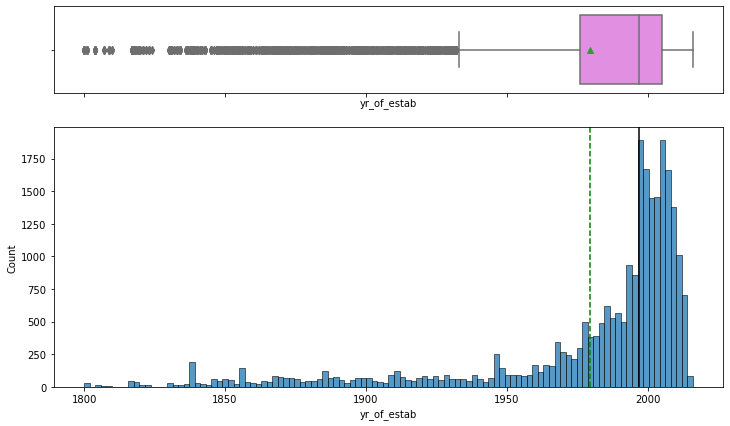

```python
histogram_boxplot(data, "yr_of_estab")
```

- The distribution of `yr_of_estab` is a highly left skewed with median close to the 21st century.
- A large range of outliers from 1800 to around 1940.
- We will explore these data more in the bivariate analysis section

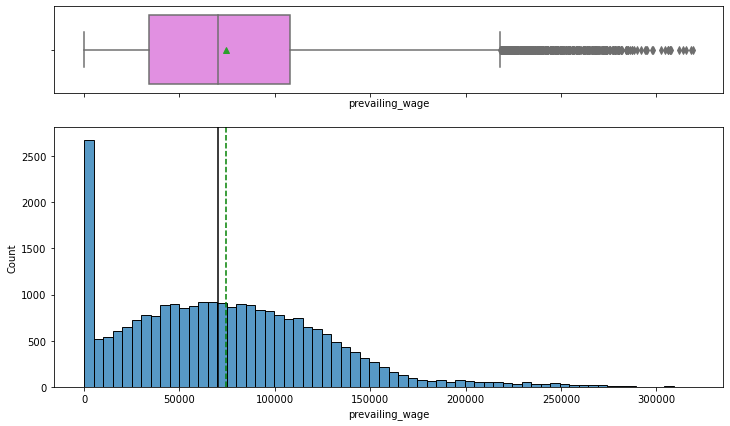

```python
histogram_boxplot(data, "prevailing_wage")
```

- The `prevailing_wage` distribution is skewed to right with a lot of outliers.
- Mean, ~75000 dollars, is slightly higher than medien, ~70000 dollars.
- There are very high counts of small `prevailing_wage`, assuming there are hourly rates or weekly rates.

```python
# function to create labeled barplots


def labeled_barplot(data, feature, perc=False, n=None):
    """
    Barplot with percentage at the top

    data: dataframe
    feature: dataframe column
    perc: whether to display percentages instead of count (default is False)
    n: displays the top n category levels (default is None, i.e., display all levels)
    """

    total = len(data[feature])  # length of the column
    count = data[feature].nunique()
    if n is None:
        plt.figure(figsize=(count + 1, 5))
    else:
        plt.figure(figsize=(n + 1, 5))

    plt.xticks(rotation=90, fontsize=15)
    ax = sns.countplot(
        data=data,
        x=feature,
        palette="Paired",
        order=data[feature].value_counts().index[:n].sort_values(),
    )

    for p in ax.patches:
        if perc == True:
            label = "{:.1f}%".format(
                100 * p.get_height() / total
            )  # percentage of each class of the category
        else:
            label = p.get_height()  # count of each level of the category

        x = p.get_x() + p.get_width() / 2  # width of the plot
        y = p.get_height()  # height of the plot

        ax.annotate(
            label,
            (x, y),
            ha="center",
            va="center",
            size=12,
            xytext=(0, 5),
            textcoords="offset points",
        )  # annotate the percentage

    plt.show()  # show the plot
```

### Continent

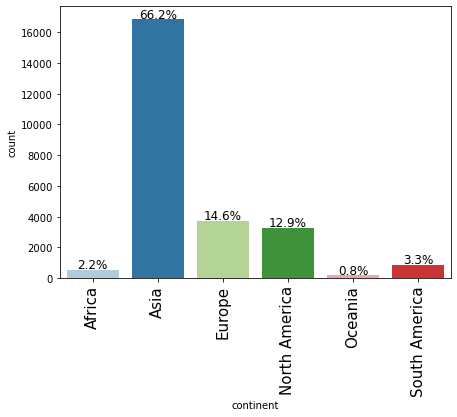

```python
labeled_barplot(data, "continent",perc=True)
```

- 66% of application were from Asia.
- Followed by Europe 14.6% abd North America 12.9%.
- Oceania has the least application, 0.8%

### Employee Education

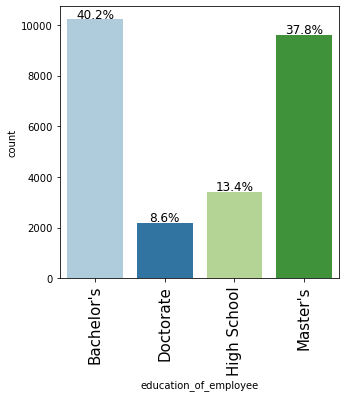

```python
labeled_barplot(data, "education_of_employee",perc=True)
```

- Most of applications are Bechelor's degree, 40.2%, and Master's, 37.8%.
- Higher school, 13.4%, and Doctorate degree, the least, 8.6%
- Most employees have need for candicates who have at least Bachelor's degree.